# SQL Business Analysis Project

```r
library(tidyverse)
library(RSQLite)
library(DBI)
```

# Create a helper function

```r
db <- 'chinook.db'

run_query <- function(query){
  conn <-  dbConnect(SQLite(), db)
  result <- dbGetQuery(conn, query)
  dbDisconnect(conn)
  return(result)
}

show_tables <- function(){
  q <- 'SELECT name, type FROM sqlite_master WHERE type IN ("table","view");'
  return(run_query(q))
}

show_tables()
```

```
##              name  type
## 1           album table
## 2          artist table
## 3        customer table
## 4        employee table
## 5           genre table
## 6         invoice table
## 7    invoice_line table
## 8      media_type table
## 9        playlist table
## 10 playlist_track table
## 11          track table
```

# Analyzing the most sold genres in USA

```r
q <- '
WITH usa AS
(SELECT * FROM customer WHERE country = "USA")
SELECT
  g.name,
  SUM(il.quantity) n_sold,
  CAST(SUM(il.quantity) AS FLOAT) / (select SUM(quantity) from invoice_line) pct_sold
FROM usa
INNER JOIN invoice i ON i.customer_id = usa.customer_id
INNER JOIN invoice_line il ON il.invoice_id = i.invoice_id
INNER JOIN track t ON t.track_id = il.track_id
INNER JOIN genre g ON g.genre_id = t.genre_id
GROUP BY g.name ORDER BY n_sold DESC;
'

genres_df <- run_query(q)
```

# Visualizing most sold genres

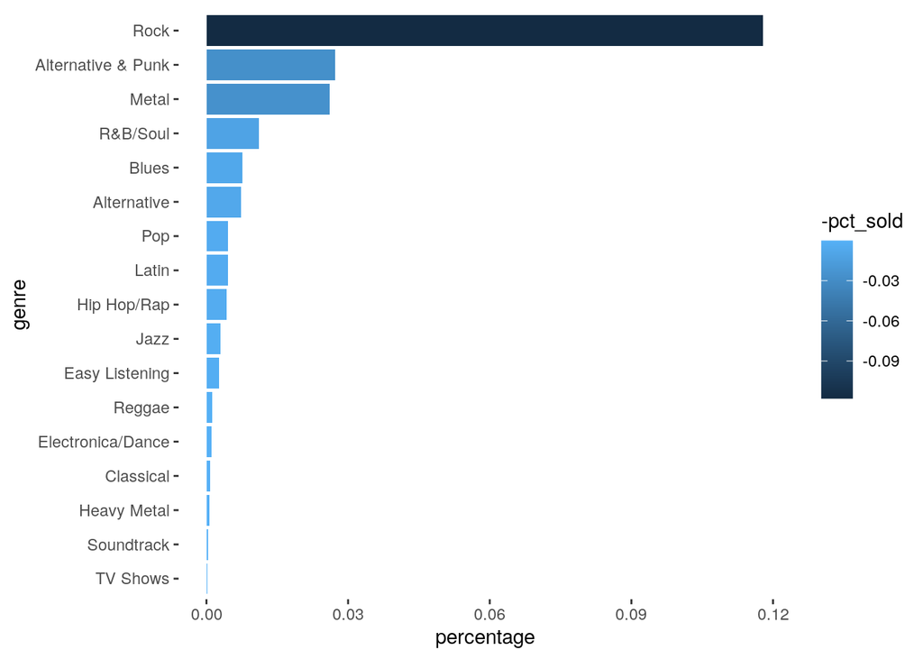

```r
genres_df %>%
  ggplot(aes(x = reorder(name, pct_sold), y = pct_sold, fill = -pct_sold)) +
  geom_col() +
  coord_flip() +
  ylab("percentage") +
  xlab("genre") +
  theme(panel.background = element_rect(fill = "white"))
```

# Sales assigned to each sales support agent within the company

```r
q_sales <- 'WITH sales_agents AS
(SELECT * FROM employee
WHERE title = "Sales Support Agent")
SELECT
  sa.first_name || " " || sa.last_name sales_agent,
  sa.reports_to,
  sa.birthdate,
  sa.hire_date,
  sa.city,
  SUM(i.total) sales_amount
FROM sales_agents sa
INNER JOIN customer c ON c.support_rep_id = sa.employee_id
INNER JOIN invoice i ON i.customer_id = c.customer_id
GROUP BY sa.employee_id
ORDER BY sales_amount DESC;
'

sales_per_agent <- run_query(q_sales)
sales_per_agent
```

```
##     sales_agent reports_to           birthdate           hire_date    city
## 1  Jane Peacock          2 1973-08-29 00:00:00 2017-04-01 00:00:00 Calgary
## 2 Margaret Park          2 1947-09-19 00:00:00 2017-05-03 00:00:00 Calgary
## 3 Steve Johnson          2 1965-03-03 00:00:00 2017-10-17 00:00:00 Calgary
##   sales_amount
## 1      1731.51
## 2      1584.00
## 3      1393.92
```

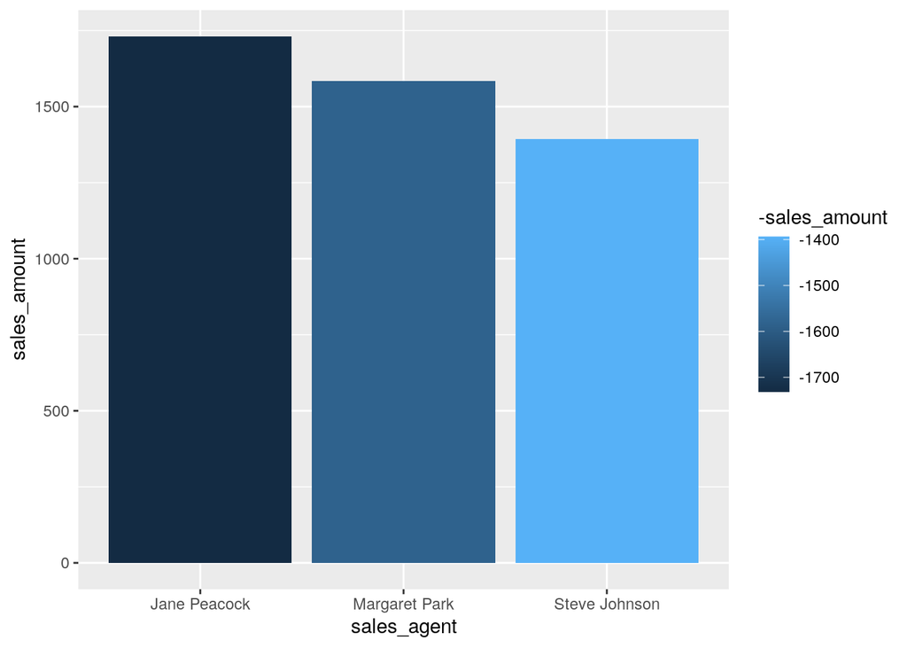

```r
sales_per_agent %>%
  ggplot(aes(x = sales_agent, y = sales_amount, fill = -sales_amount)) +
  geom_col()
```

From the information we have, the three sales agents are from the same city (Calgary), and they are hired in the same year, but the person with more experience is the agent with more sales. She is also the youngest. Female agents sale more than the male agent.

# Analyze the sales data for customers from each country

```r
# Total number of customers
# Total value of sales
# Average value of sales per customer
# Average order value

q_country <- 'WITH country_sales AS
(SELECT
  c.country,
  COUNT(distinct c.customer_id) n_customers,
  SUM(i.total) total_sales,
  SUM(i.total) / COUNT(distinct c.customer_id) avg_sale,
  COUNT(distinct i.invoice_id) n_invoices,
  SUM(i.total) / COUNT(distinct i.invoice_id) avg_invoice
FROM customer c
INNER JOIN invoice i ON i.customer_id = c.customer_id
INNER JOIN invoice_line il ON il.invoice_id = i.invoice_id
GROUP BY c.country)

SELECT
  country_grouped,
  total_customers,
  total_sales,
  avg_sale,
  avg_invoice
FROM
(SELECT
  CASE
    WHEN n_customers = 1 THEN "Others"
    ELSE country
    END AS country_grouped,
  CASE
    WHEN n_customers = 1 THEN 1
    ELSE 0
    END AS sort,
  SUM(n_customers) total_customers,
  SUM(total_sales) total_sales,
  SUM(total_sales) / SUM(n_customers) avg_sale,
  SUM(total_sales) / SUM(n_invoices) avg_invoice
FROM country_sales
GROUP BY country_grouped
ORDER BY sort ASC, total_sales DESC);


'
sales_by_country <- run_query(q_country)
sales_by_country
```

```
##    country_grouped total_customers total_sales  avg_sale avg_invoice
## 1              USA              13    10405.89  800.4531    79.43427
## 2           Canada               8     5489.55  686.1937    72.23092
## 3           Brazil               5     4059.00  811.8000    66.54098
## 4           France               5     3972.87  794.5740    79.45740
## 5          Germany               4     3441.24  860.3100    83.93268
## 6   Czech Republic               2     3183.84 1591.9200   106.12800
## 7   United Kingdom               3     2498.76  832.9200    89.24143
## 8            India               2     1887.93  943.9650    89.90143
## 9         Portugal               2     1755.27  877.6350    60.52655
## 10          Others              15    10808.82  720.5880    73.52939
```

USA is the country with more total sales and more customers, followed by Canada and Brazil by far. The average sale for Czech Republic is the highest.

# Visualizing sales by country

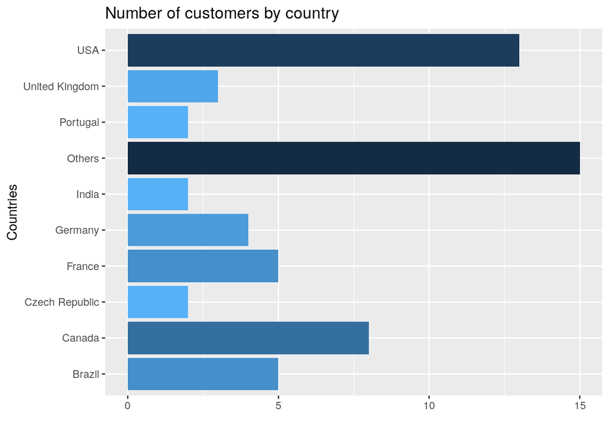

```r
# Number of customers by country
sales_by_country %>%
  ggplot(aes(x=country_grouped, y = total_customers, fill = -total_customers)) +
  geom_col(show.legend = FALSE) +
  coord_flip() +
  labs(title = "Number of customers by country", x = "Countries", y = "")
```

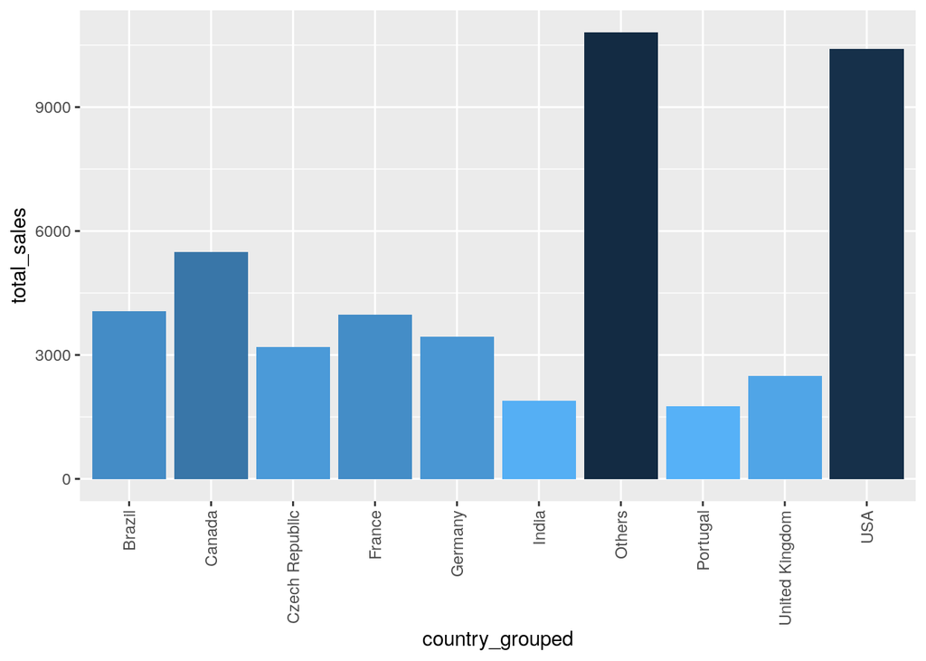

```r
# Total sales by country
sales_by_country %>%
  ggplot(aes(x = country_grouped, y = total_sales, fill = -total_sales)) +
  geom_col(show.legend = FALSE) +
  theme(axis.text.x = element_text(angle = 90, vjust = 0.5, hjust=1))
```

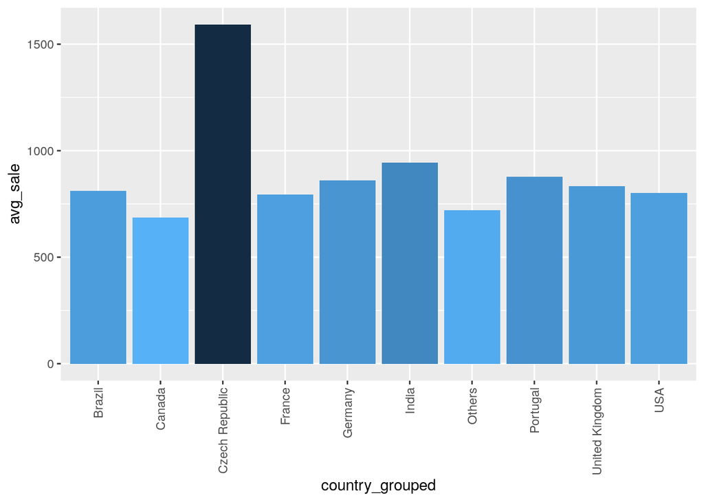

```r
# Average sale by country
sales_by_country %>%
  ggplot(aes(x = country_grouped, y = avg_sale, fill = -avg_sale)) +
  geom_col(show.legend = FALSE) +
  theme(axis.text.x = element_text(angle = 90, vjust = 0.5, hjust=1))
```

USA is the country with most sales and Czech Republic the market with highest average sale. This two countries look the more interesting for investment.

# What percentage of purchases are individual tracks versus whole albums

1. Identifying if an invoice contains all the tracks from an album list of tracks from an invoice and comparing it to the list of tracks from an album. whether the exception of two subqueries IS NULL (the two groups have the same elements)

GOALS: Categorize each invoice as either an album purchase or not, and calculates the following summary statistics:

- Number of invoices
- Percentage of invoices